# What sets European regions apart?

## Random Forest

```r
param_grid = expand.grid(predFixed = seq(10, 20, 5), # Number of Randomly Selected Predictors
                         minNode = seq(3, 7, 1)) # Minimal Node Size
set.seed(123)
rf_regression <- train(gross_domestic_product ~ .,
                       data = training,
                       method = "Rborist",
                       tuneGrid = param_grid,
                       metric= "RMSE",
                       preProcess = c("scale", "center"),
                       trControl = ctrl,
                       verbose = FALSE)
```

```r
rf_regression$bestTune
```

```
##    predFixed minNode
## 13        20       5
```

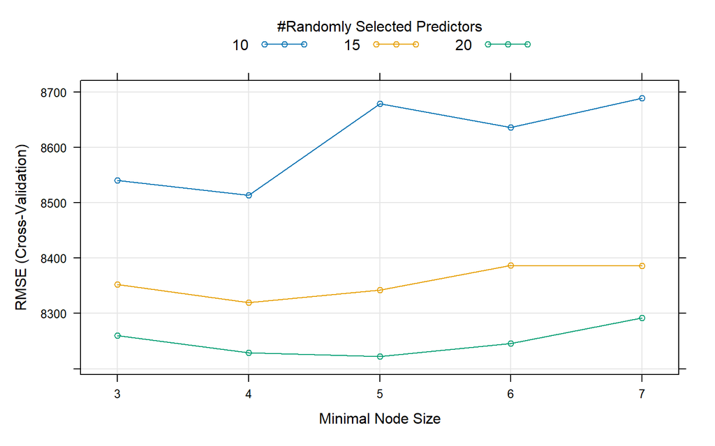

```r
plot(rf_regression)
```

20 predictors (basically the whole dataset) seems to be constantly better than less predictors. Further confirming that all my variables are relevant in the prediction process.

```r
predictions_rf <- predict(rf_regression,
                           newdata=testing,
                           type="raw")
round(postResample(pred = predictions_rf,
                   obs = testing$gross_domestic_product),3)
```

```
##      RMSE  Rsquared       MAE
## 10003.765     0.783  5670.729
```

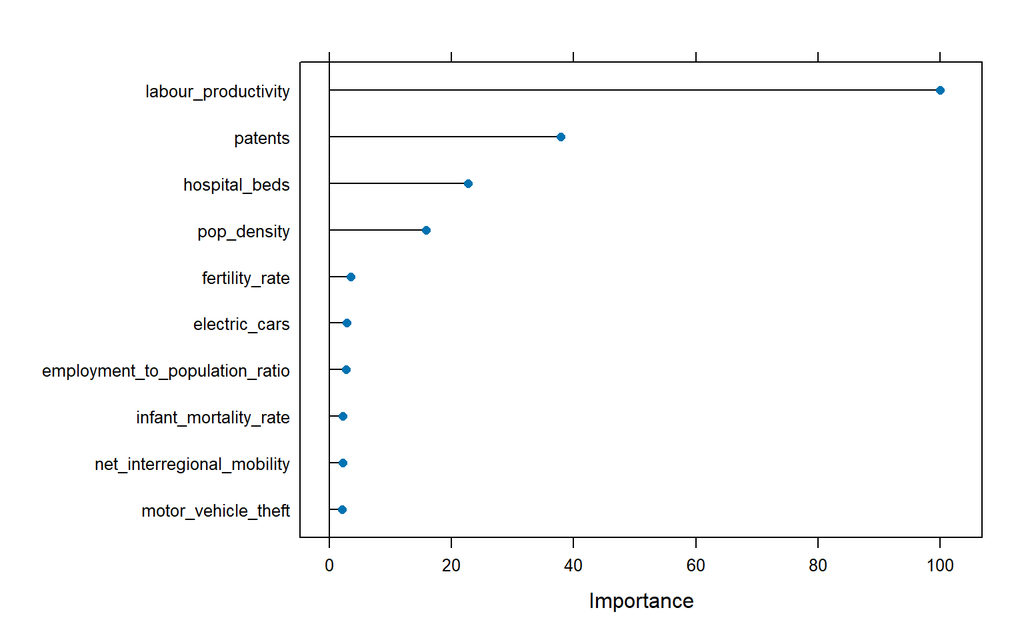

```r
rf_imp <- varImp(rf_regression)
plot(rf_imp, top=10)
```

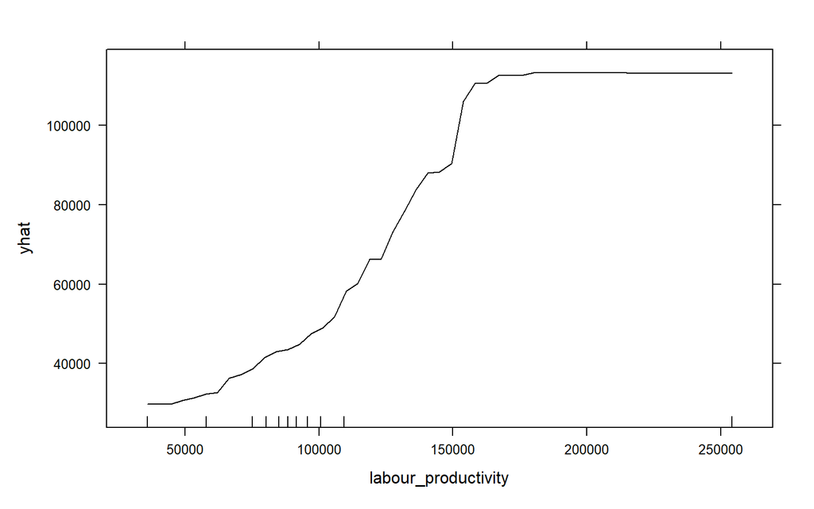

```r
partial(rf_regression, pred.var = "labour_productivity",
        plot = TRUE, rug = TRUE)
```

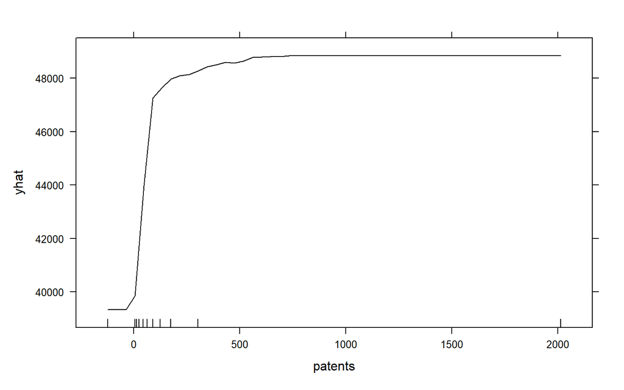

```r
partial(rf_regression, pred.var = "patents",
        plot = TRUE, rug = TRUE)
```

`labour_productivity` has a very similar pattern as the one that was found for KNN. This time seems even more linear. `patents` instead shows a sudden increase, but still a positive relationship with the target variable (i.e. more patents more GDP).

## Gradient Boosting

```r
param_grid = expand.grid(n.trees = c(300, 500, 700), # Number of Boosting Iterations
                         interaction.depth = c(10, 20, 30),  # Max Tree Depth
                         shrinkage = c(0.001, 0.01, 0.1), # Shrinkage
                         n.minobsinnode = c(2, 5, 10)) # Min. Terminal Node Size
set.seed(123)
gb_regression <- train(gross_domestic_product ~ .,
                       data = training,
                       method = "gbm",
                       tuneGrid = param_grid,
                       metric= "RMSE",
                       trControl = ctrl,
                       preProcess = c("scale", "center"),
                       verbose = FALSE)
```

```r
gb_regression$bestTune
```

```
##    n.trees interaction.depth shrinkage n.minobsinnode
## 39     700                20      0.01              2
```

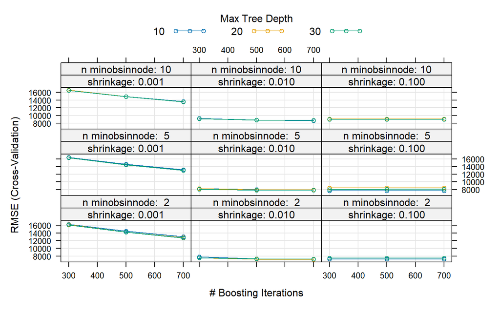

```r
plot(gb_regression)
```

```r
predictions_gb <- predict(gb_regression,
                           newdata=testing,
                           type="raw")
round(postResample(pred = predictions_gb,  obs = testing$gross_domestic_product),3)
```

```
##     RMSE Rsquared      MAE
## 9151.606    0.816 5278.269
```

The predictive power of the gradient boosting model is greater than that of the random forest (gradient boosting is better in across all metrics), but it seems slightly worse than Elastic Net. Gradient boosting has a lower R squared (0.81 vs 0.85) and higher RMSE, however it has the lowest mean absolute error by far. The lower MAE suggests that gradient boosting makes fewer large mistakes, but on the other hand, that it does not understand the dataset as well as the linear regression which explain a higher proportion of variability.

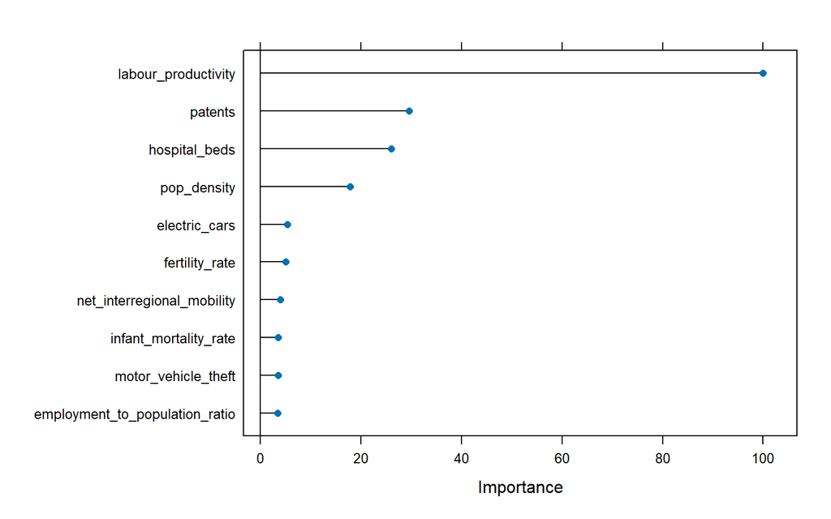

```r
gb_imp <- varImp(gb_regression)
plot(gb_imp, top=10)
```

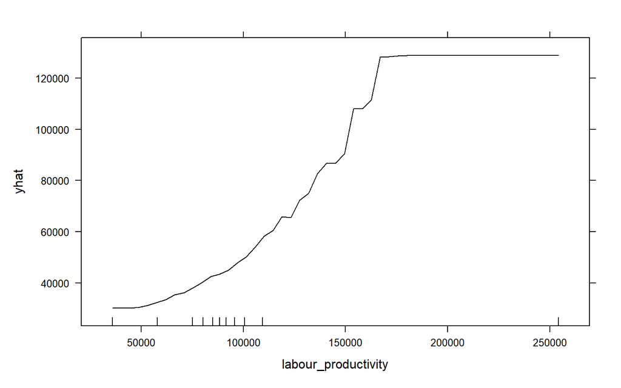

```r
partial(gb_regression, pred.var = "labour_productivity",
        plot = TRUE, rug = TRUE)
```

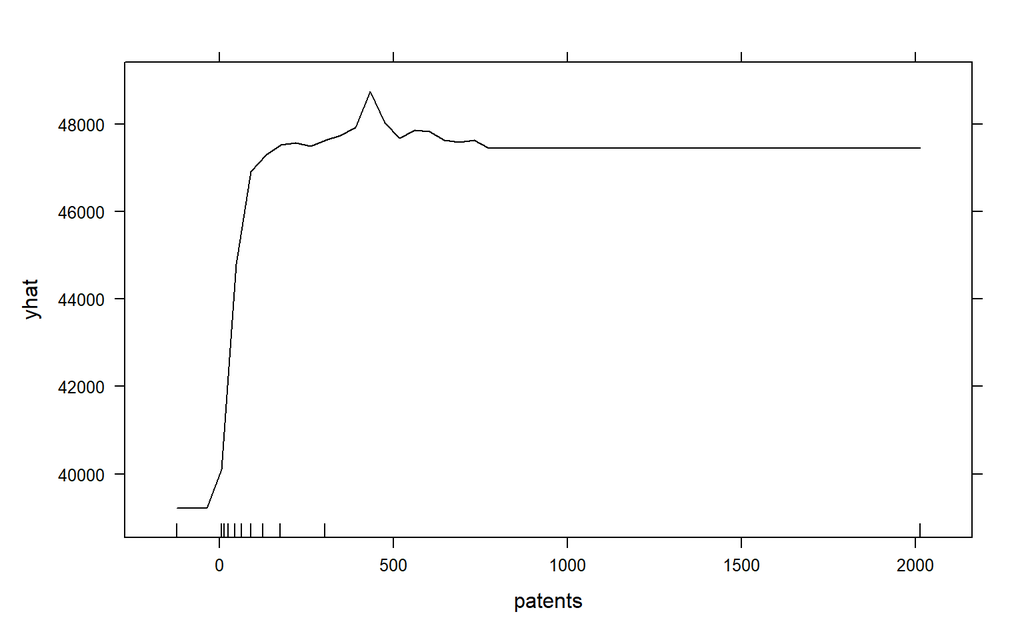

```r
partial(gb_regression, pred.var = "patents",
        plot = TRUE, rug = TRUE)
```

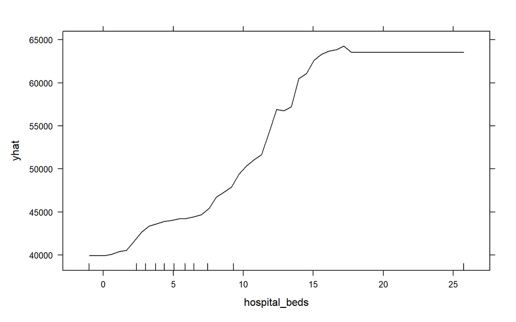

```r
partial(gb_regression, pred.var = "hospital_beds",
        plot = TRUE, rug = TRUE)
```

The top predictors are always the same, constant across all models.

Even the relationship between `labour_productivity` and `gross_domestic_product` is akin to that of previous models, suggesting that `labour_productivity` has a strong positive linear relationship to GDP up to a certain threshold where after that it is no longer able to explain further increases in GDP.

Patents’ partial dependency plot is really similar to the random forest one, showing a steep increase for low values of `patents`.

Lastly, also `hospital_beds` has a positive linear relationship with `gross_domestic_product`up to a certain threshold, showing that a higher number of beds in an hospital is a good predictor of higher GDP.

Notably the scale of the y-axis for `labour_productivity` is way longer than for the rest of the measures, suggesting even more that this variable is the main predictor of GDP as it is able to explain much more of its variability than the rest of the variables.

## Neural Network

```r
param_grid = expand.grid(layer1 = c(4, 2),
                         layer2 = c(2, 1, 0),
                         layer3 = c(0)) # Layers neural network
set.seed(123)
nn_regression <- train(gross_domestic_product ~ .,
                       data = training,
                       method = "neuralnet",
                       tuneGrid = param_grid,
                       metric= "RMSE",
                       trControl = ctrl,
                       preProcess = c("scale", "center"))
```

```r
nn_regression$bestTune
```

```
##   layer1 layer2 layer3
## 4      4      0      0
```

This neural network has 4 nodes in the first layer, but just 1 layer.

```r
predictions_nn <- predict(nn_regression,
                           newdata=testing,
                           type="raw")
round(postResample(pred = predictions_nn,
                   obs = testing$gross_domestic_product),3)
```

```
##      RMSE  Rsquared       MAE
## 20893.043     0.007 13433.126
```

This neural network is incredibly bad at predicting. The MAE and RMSE are actually the same as the mean based benchmark indicating that this neural network is likely returning a simple average.

This confirms that neural network are not the best for small datasets of tabular data, with simple relationships.

## Summary

```r
summary <- bind_rows(round(postResample(pred = predictions_benchmark,
                             obs = testing$gross_domestic_product),3),
          round(postResample(pred = predictions_linear,
                             obs = testing_scaled$gross_domestic_product),3),
          round(postResample(pred = predictions_caret_sw,
                             obs = testing_dummies$gross_domestic_product),3),
          round(postResample(pred = predictions_elnet,
                             obs = testing_dummies$gross_domestic_product),3),
          round(postResample(pred = predictions_knn,
                             obs = testing$gross_domestic_product),3),
          round(postResample(pred = predictions_dt,
                             obs = testing$gross_domestic_product),3),
          round(postResample(pred = predictions_rf,
                             obs = testing$gross_domestic_product),3),
          round(postResample(pred = predictions_gb,
                             obs = testing$gross_domestic_product),3),
          round(postResample(pred = predictions_nn,
                             obs = testing$gross_domestic_product),3))

sigma_gdp <- sd(training$gross_domestic_product)

summary <- summary |>
  mutate(
    # Unscale RMSE only for the second row
    RMSE = ifelse(row_number() == 2, RMSE * sigma_gdp, RMSE),
    # Unscale MAE only for the second row
    MAE = ifelse(row_number() == 2, MAE * sigma_gdp, MAE))

Model <- c("Benchmark", "Linear Regression", "Stepwise",
           "Elastic Net", "KNN", "Decision Tree",
           "Random Forest", "Gradient Boosting", "Neural Network")

summary <- cbind(Model, summary)
summary
```

```
##               Model      RMSE Rsquared       MAE
## 1         Benchmark 20893.043       NA 13433.126
## 2 Linear Regression  7962.567    0.843  5907.067
## 3          Stepwise  8146.177    0.849  5803.182
## 4       Elastic Net  8118.192    0.851  5770.069
## 5               KNN 13862.056    0.579  6935.148
## 6     Decision Tree 14252.966    0.541  9709.934
## 7     Random Forest 10003.765    0.783  5670.729
## 8 Gradient Boosting  9151.606    0.816  5278.269
## 9    Neural Network 20893.043    0.007 13433.126
```

To build my ensemble I will use Elastic-Net (the best out of the linear models), gradient boosting and random forest, which are the three type of models that provide the best predictions.

## Ensemble

```r
ensemble_pred <- (predictions_elnet + predictions_gb + predictions_rf)/3

round(postResample(pred = ensemble_pred,
                   obs = testing$gross_domestic_product),3)
```

```
##     RMSE Rsquared      MAE
## 8564.057    0.843 5089.490
```

The R-squared of the ensemble is good, almost as high as any of the individual models. The MAE is actually lower than any other individual model suggesting that the right models were picked and highlighting the utility of building an ensemble combining predictions from different models.

### Predictions vs actual

```r
testing_regions <- char_col[-in_train,]
final_table <- tibble(
  region = testing_regions$region_name,
  country = testing_regions$country_name,
  continental_region = testing_regions$continental_region,
  predictions = ensemble_pred,
  actual = testing$gross_domestic_product,
  error = predictions - actual
)

head(final_table |> arrange(abs(error)))
```

```
## # A tibble: 6 × 6
##   region                    country continental_region predictions actual error
##   <chr>                     <chr>   <fct>                    <dbl>  <dbl> <dbl>
## 1 Esslingen                 Germany Western                 60698. 60710. -12.3
## 2 Northern Denmark          Denmark Northern                50903. 50921. -17.7
## 3 Arr. Namur                Belgium Western                 43582. 43622. -39.3
## 4 Rostock, Kreisfreie Stadt Germany Western                 52098. 52057.  41.5
## 5 Päijät-Häme (TL2021)      Finland Northern                42268. 42220.  47.3
## 6 Lot                       France  Western                 36479. 36428   51.1
```

```r
tail(final_table |> arrange(abs(error)))
```

```
## # A tibble: 6 × 6
##   region                   country continental_region predictions actual   error
##   <chr>                    <chr>   <fct>                    <dbl>  <dbl>   <dbl>
## 1 City of Warsaw           Poland  Eastern                 71151. 9.24e4 -21223.
## 2 Heilbronn, Stadtkreis    Germany Western                 57297. 8.12e4 -23890.
## 3 Düsseldorf, Kreisfreie … Germany Western                 94266. 1.19e5 -24238.
## 4 Dingolfing-Landau        Germany Western                 69483. 9.47e4 -25259.
## 5 Bratislava Region        Slovak… Eastern                 49466. 7.84e4 -28940.
## 6 Wolfsburg, Kreisfreie S… Germany Western                139294. 2.27e5 -88190.
```

I will now make a graph to analyze patterns within my residuals:

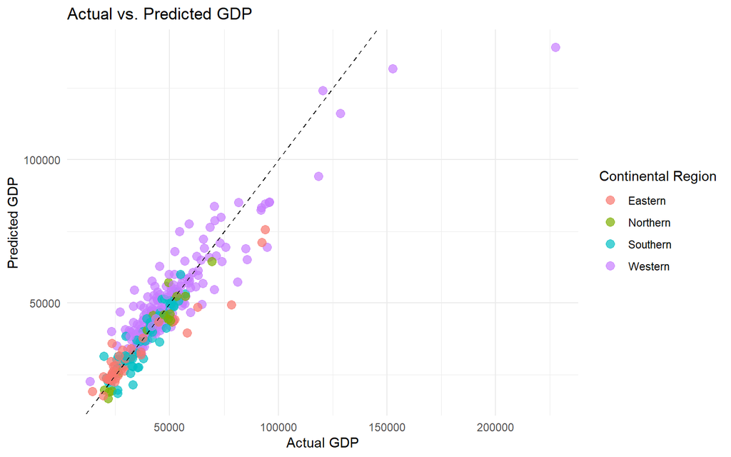

```r
options(scipen = 999)
ggplot(final_table, aes(x = actual, y = predictions, color = continental_region)) +
  geom_point(alpha = 0.7, size = 3) +
  geom_abline(slope = 1, intercept = 0, linetype = "dashed", color = "black") +
  labs(
    title = "Actual vs. Predicted GDP",
    x = "Actual GDP",
    y = "Predicted GDP",
    color = "Continental Region"
  ) +
  theme_minimal()
```

It seems like the ensemble is able to predict fairly well in all the subregions of Europe. Struggling only with outliers for extreme values of `gross_domestic_product`.

## Prediction interval

Building and plotting prediction intervals:

```r
error <- testing$gross_domestic_product - ensemble_pred
noise <- error[1:100]
lwr <- ensemble_pred[101:length(ensemble_pred)] + quantile(noise,0.05, na.rm=T)
upr <- ensemble_pred[101:length(ensemble_pred)] + quantile(noise,0.95, na.rm=T)
predictions <- tibble(actual = testing$gross_domestic_product[101:length(testing$gross_domestic_product)],
                      fit = ensemble_pred[101:length(ensemble_pred)],
                      lwr = lwr,
                      upr = upr,
                      continental_region = testing_regions$continental_region[101:length(testing_regions$continental_region)])
predictions <- predictions |> mutate(out = factor(if_else(actual<lwr | actual>upr,1,0)))

mean(predictions$out==1)
```

```
## [1] 0.05
```

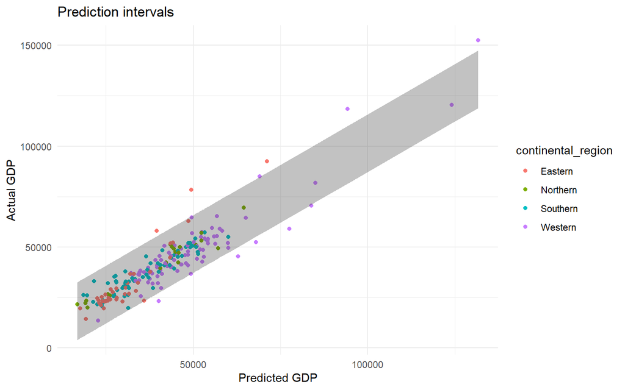

```r
ggplot(predictions, aes(x = fit, y = actual))+
  geom_point(aes(color = continental_region)) +
  theme_minimal() +
  geom_ribbon(data = predictions, aes(ymin = lwr, ymax = upr), alpha=0.3) +
  labs(title = "Prediction intervals", x = "Predicted GDP",y = "Actual GDP")
```

Basically all the observations in the testing set would actually fall within the predicted interval, with only few of them falling just outside.

This further confirm the robustness and validity of the models I have built and then combined in the final ensemble.

# Final thoughts

Throughout this document I have built and then analyzed several classification and logistic models. The classification models aimed at classifying my observations into their continental subregion (Eastern, Western, Northern or Southern Europe). The regression models aimed at predicting GDP per capita of the NUTS-3 regions of the EU.

Even if limited by time and computational power during model training, I was able to obtain good predictive models. Across most of the models the variables that were the most important for prediction were constantly the same. These variables also where coherent with common knowledge and/or academic literature on the topic. For example Southern Europe seemed characterized by lower age adjusted mortality rate and lower employment, while Northern Europe regions tended to be less characterized by pollution. Labour productivity was found to be an important predictor of GDP, but important proxies also seemed to be the number of hospital beds and the number of patents’ applications.

It is also worth mentioning that although I have not applied any logarithmic transformation since most machine learning methods do not specifically need that, some of my variables are severely skewed and this could have further helped predictions especially for statistical learning methods.

Overall the excercise was a good learning process that allowed me to implement many different models, compare them, understand their strength and weaknesses and interpret their results.